This Jupyter notebook and the others in the same folder act as supporting materials for **Chapter 22 Reinforcement Learning** of the book* Artificial Intelligence: A Modern Approach*. The notebooks make use of the implementations in `reinforcement_learning4e.py` module. We also make use of the implementation of MDPs in the `mdp4e.py` module to test our agents.

```python
import os, sys
sys.path = [os.path.abspath("../../")] + sys.path
from reinforcement_learning4e import *
```

# Passive Reinforcement Learning

To demonstrate these agents, we make use of the `GridMDP` object from the `MDP` module. `sequential_decision_7x6_environment` is similar to that used for the `MDP` notebook but has discounting with $\gamma = 0.9$ and a 7x6 environment.

# 1. uzdevums

Jāizvēlas konkrēta vides konfigurācija, kurā ne vairāk kā 5 lauciņos aģents nespēj ieiet, t. i. vidē gadījuma ceļā jāizvieto ne vairāk kā 5 šķēršļi. Jāizvēlas pietiekami atšķirīgas balvu vērtības diviem galējiem stāvokļiem (viena balva ir pozitīva, bet otra negatīva).

a) Šķēršļi ir (0,3) (1,1) (3,5) (5,5)

b) Balvas ir +1 un -1

# 2. uzdevums

Jāizvēlas aģentu darbības stohastisks modelis, kas specificē to, ka aģents no lauciņa, kurā tas pašlaik atrodas, vienā solī nokļūst uz lauciņa nodomātajā virzienā ar varbūtību 0.6. Trīs pārējos virzienos (divos perpendikulāros nodomātajam virzienam un pretēji tam), kuros aģentu pārvieto stohastiskā vide, varbūtības jāspecificē šādi: varbūtība, ka vide aģentu pārvietos nodomātajam virzienam pretējā virzienā ir mazāka nekā varbūtība, ka aģentu vide pārvietos pa labi no nodomātā virziena, bet pēdējā, savukārt ir lielāka nekā varbūtība, ka vide to pārvietos pa kreisi no nodomātā virziena (obligāta prasība ir, ka aģents spēj pārvietoties visos 4 nodomātajos virzienos – augšup, lejup, pa labi, pa kreisi).

a) Uz “priekšu” = 0.6

b) Pretēji = 0.1 (mazāks nekā pa labi)

c) Pa labi = 0.17

d) Pa kreisi = 0.13 (mazāks nekā pa labi)

```python
from mdp4e import sequential_decision_7x6_environments
environments = sequential_decision_7x6_environments
```

[figure not shown]

The `sequential_decision_7x6_environment` is a GridMDP object. The rewards are **+1** and **-1** in the terminal states. Now we define actions and a policy similar to **Fig 22.1** in the book.

Ar konkrētiem aprēķiniem, izmantojot 2. - 5. punktā aprakstītās darbības, jāparāda, kā mainās aģenta politika pie trim dažādām izmaksu vērtībām par atrašanos katrā no lauciņiem: (-1,2), (-0,5) un (-0,06).

# 3. uzdevums

Jāizvēlas fiksēta politika, lietojot vērtību iterāciju metodi (politikas izvēle jābalsta uz vismaz tik daudz iterācijām, kas ir pietiekamas, lai aģents viennozīmīgi spētu izvēlēties darbību katrā no vides stāvokļiem), un jāapmāca aģents, lietojot lietderību tiešās novērtēšanas metodi pasīvā apmācībā.

```python
from mdp4e import best_policy, value_iteration
import matplotlib.pyplot as plt
import numpy as np
from utils4e import print_table
```

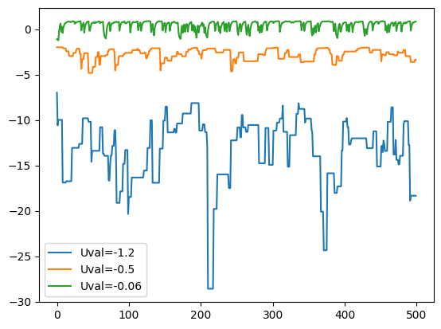

```
>      >      v   None   v   None   .
>      >      >   >      >   >      ^
None   >      >   ^      ^   ^      .
>      >      ^   ^      ^   ^      <
^      None   ^   ^      ^   ^      <
>      >      ^   ^      ^   ^      <
```

```python
u_val = [-1.2, -0.5, -0.06]

for envN in range(3):
    policy = best_policy(environments[envN], value_iteration(environments[envN]))
    agent3 = PassiveDUEAgent(policy, sequential_decision_7x6_environments[envN])

    yvals = []
    xvals = []
    for i in range(500):
        run_single_trial(agent3, sequential_decision_7x6_environments[envN])
        agent3.estimate_U()
        xvals.append(i)
        yvals.append(list(agent3.U.items())[5][1])

    plt.plot(np.array(xvals), np.array(yvals), label = "Uval="+str(u_val[envN]))
plt.legend()
plt.show()
print_table(environments[0].to_arrows(policy))
```

# Secinājumi:

1. tā kā aģents sāk mācīties uz ideālas polises, tad jaunie vērtējumi parasti fluktuē kādā diapazonā ar retiem izņēmumiem, kad stohastiskas vides ietekmē tiek novēroti extrēmi gadījumi. Pasīvā modeļa uzlabojumi nenotiek.
2. jo lielāka izmaksas vērtība par katru soli, jo lielāks var būt šis diapazons
3. šāda likumsakarība ir novērojama neatkarīgi no attāluma līdz pēdējam stāvoklim

# 4. uzdevums

Lietojot gadījuma skaitļu ģeneratoru, jāiegūst 20 stāvokļu pāreju secības.

```python
from mdp4e import random_policy
from utils4e import print_table
policies = []
for i in range(20):
    policies.append(random_policy(environments[0]))
print_table(environments[0].to_arrows(policies[5]))
print("-----------------------------------")
print_table(environments[0].to_arrows(policies[10]))
```

```
>      ^      v   None   >   None   .
>      >      >   <      >   <      >
None   >      ^   ^      v   >      .
^      <      ^   v      <   v      v
^      None   v   <      v   ^      >
<      >      <   >      <   <      >
-----------------------------------
v      ^      <   None   v   None   .
^      <      >   v      ^   v      >
None   ^      v   <      <   ^      .
v      ^      >   <      ^   <      <
^      None   ^   v      <   ^      >
<      >      ^   ^      >   ^      v
```

# 5. uzdevums

Izmantojot iegūtās secības kā apmācības kopu, jāveic aģenta pasīvā apmācība šādos gadījumos:

a) jāapmāca adaptīvās dinamiskās programmēšanas aģents, 22.2.2 ADP

b) jāapmāca aģents, lietojot laika starpības apmācību, 22.2.3 TD

c) jāapmāca aģents, lietojot tiešo lietderību novērtēšanu. 22.2.1 DUE

Savukārt 5c. punktā aģents tiešo atjaunināšanu veic katrā no 20 gadīijumiem, protams , ievērojot iepriekšējos gadījumos iegūtos lietderību novērtējumus. Protams, apmācība ir iteratīva, un pāreju modelis mainās ik pēc jauna piemēra (secības) iegūšanas. bet šajā gadījumā tiek pieļauts, ka doktorantam nav obligāti jāprogrammē un, risinot manuāli, var izmantot pāreju modeli, kas iegūts, realizējot visu apmācības kopu.

5. Uzdevuma aģentam politika ir jāiemācās no nulles.

Katru tālāko uzdevumu tehniski nav problēmu palaist katrai no 20 stāvkoļu pāreju secībām pie 3 dažādām izmaksu vērtībām, bet tā kā rezultātu būtu grūti vizualizēt, tad pētījumiem tiks izmantoti mazāk gadījumi, kas ir pietiekams daudzums.

## 5c) Direct Utility Estimation (DUE)

[figure not shown]

```python
import matplotlib.pyplot as plt
p = 20
pi = 2 #20 in total
ei = 1 # 3 in total


for pi in range(p):
    lines = []
    for i in range (6*7):
        line = []
        lines.append(line)
    DUEagent = PassiveDUEAgent(policies[pi], sequential_decision_7x6_environments[ei])
    xvals = []
    for i in range(500):
        run_single_trial(DUEagent, sequential_decision_7x6_environments[ei])
        DUEagent.estimate_U()
        xvals.append(i)
        for posi in range(6*7):
            try:
                lines[posi].append(list(DUEagent.U.items())[posi][1])
            except:
                lines[posi].append(0)

    plt.subplot(p, 1, pi+1)
    for posi in range(6*7):
#        plt.plot(np.array(xvals), np.array(lines[posi]), label = "Uval="+str(u_val[ei])+"pos="+str(posi))
        plt.plot(np.array(xvals), np.array(lines[posi]))

#plt.legend()
plt.show()
```

# Secinājumi:

Augstākie grafiki rāda pasīvā aģenta katras lauciņa pozīcijas vērtību pa iterācijām (apmācīšanās progresu). Rezultāti izskatās līdzīgi neatkarīgi no sākuma gadījuma polises.

Sekojošais kods apmāca DUE aģentus ar trīs dažādām izmaksu vērtībām:

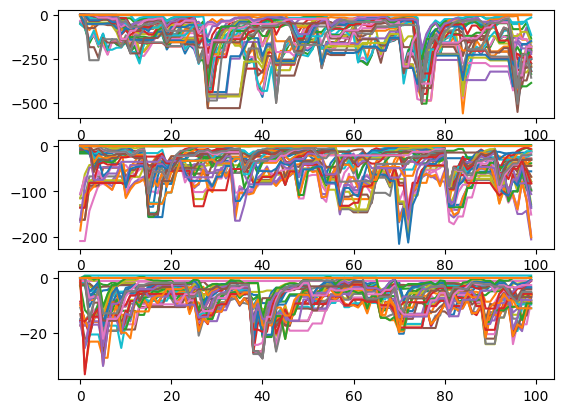

```python
import matplotlib.pyplot as plt
pi = 2 #20 in total
e = 3
ei = 1 # 3 in total


for ei in range(e):
    lines = []
    for i in range (6*7):
        line = []
        lines.append(line)
    DUEagent = PassiveDUEAgent(policies[pi], sequential_decision_7x6_environments[ei])
    xvals = []
    for i in range(100):
        run_single_trial(DUEagent, sequential_decision_7x6_environments[ei])
        DUEagent.estimate_U()
        xvals.append(i)
        for posi in range(6*7):
            try:
                lines[posi].append(list(DUEagent.U.items())[posi][1])
            except:
                lines[posi].append(0)

    plt.subplot(e, 1, ei+1)
    for posi in range(6*7):
#        plt.plot(np.array(xvals), np.array(lines[posi]), label = "Uval="+str(u_val[ei])+"pos="+str(posi))
        plt.plot(np.array(xvals), np.array(lines[posi]))

#plt.legend()
plt.show()
```

# Secinājumi:

Līdzīgi kā 3. uzdevumā, diapazons ir atkarīgs no izmaksas vērtības. Izskatās, ka aģents ātri atrod optimumu un attīstība nenotiek, tikai pārmācīšanās.

## 5a) Adaptive Dynamic Programming (ADP)

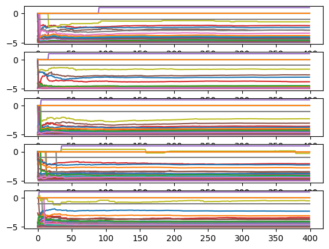

```python
import matplotlib.pyplot as plt
p = 5
pi = 2 #20 in total
ei = 1 # 3 in total


for pi in range(p):
    lines = []
    for i in range (6*7):
        line = []
        lines.append(line)
    ADPagent = PassiveADPAgent(policies[pi], sequential_decision_7x6_environments[ei])
    xvals = []
    for i in range(400):
        run_single_trial(ADPagent, sequential_decision_7x6_environments[ei])
        xvals.append(i)
        for posi in range(6*7):
            try:
                lines[posi].append(list(ADPagent.U.items())[posi][1])
            except:
                lines[posi].append(0)

    plt.subplot(p, 1, pi+1)
    for posi in range(6*7):
        plt.plot(np.array(xvals), np.array(lines[posi]))

plt.show()
```